# summary

### **Video Prediction Project - Lab CudaVision**

- Student 1
- Student 2
- 1. Import Required Modules
- 2. Datasets
  - 2.1 Moving MNIST
  - 2.2 KTH
  - 2.3 Train/Test Dotaloader Statistics
- 3. Models Architectures
  - 3.1 Resnet18-style Encoder-Decoder
  - 3.2 VGG19-style Encoder-Decoder
  - 3.3 DCGAN-style Encoder-Decoder
  - 3.4 ConvLSTM
  - 3.5 Models #Parameters Statistics
- 4. Training Experiments
  - Training model
  - Visualizing Logs
- 5. Results
  - 5.1 Results on MMNIST
    - 5.1.1 Visualize Best Metrices
    - 5.1.2 Visualize Output for Random Samples
    - 5.1.3 Models Comparison
  - 5.2 Results on KTH
    - 5.2.1 Visualize Best Metrices
    - 5.2.2 Visualize Output for Random Samples
    - 5.2.3 Models Comparison
- 6. References

### Project Structure

```
.
├── checkpoints         # saving trained models
├── configs             # configs used for different experiments
├── data                # data directory
│   └── KTH
│   └── MMNIST
├── model_eval          # scripts for evaluating trained models
├── models              # building blocks of the model
├── metrics_data        # stored data of computed metrics
├── results             # some images/GIFs computed from trained model
├── tboard_logs         # logs from our experiments
├── utils               # contains trainer to train model and some extra functionalities
└── eval.py
└── train.py
└── summary.ipynb
```

### **1. Importing Required Module**

```python
import os
import torch
from prettytable import PrettyTable
from utils.visualizations import save_grid_batch, save_gif_batch
from utils.utils import eval_dataset, count_model_params
from models.resnet import Resnet18Encoder, Resnet18Decoder
from models.vgg import VGGEncoder, VGGDecoder
from models.dcgan import DCGANEncoder, DCGANDecoder
from models.predictorLSTM import predictor
from eval import eval
import matplotlib.pyplot as plt

%load_ext autoreload
%autoreload 2
device = torch.device("cuda" if torch.cuda.is_available() else "cpu")
```

### **2. Datasets**

**NOTE** Running the codde first time might take some time to download the datasets in respective folders

#### **2.1 Moving MNIST**

```python
mmnist_test_loader = eval_dataset(dataset = "MMNIST", batch_size=20)
```

```python
sample_batch = next(iter(mmnist_test_loader))
print("batch shape: (seq_len, batch_size, channels, height, width")
sample_batch.shape
```

[output not shown]

```python
save_grid_batch(sample_batch, nsamples=5, text = "mmnist_test", show = True)
```

[output not shown]

```python
save_gif_batch(sample_batch, nsamples =5, text = "mmnist_test", show =True)
```

#### **2.2 KTH**

```python
kth_test_loader = eval_dataset(dataset = "KTH", batch_size=20)
```

```python
sample_batch = next(iter(kth_test_loader))
print("batch shape: (seq_len, batch_size, channels, height, width")
sample_batch.shape
```

[output not shown]

```python
save_grid_batch(sample_batch, nsamples=5, text = "kth_test", show = True)
```

[output not shown]

```python
save_gif_batch(sample_batch, nsamples =5, text = "kth_test", show =True)
```

### **3. Models Architectures**

#### **3.1 Resnet18-style Encoder-Decoder**

```python
resnet_encoder = Resnet18Encoder()
resnet_encoder = resnet_encoder.to(device)
resnet_encoder
```

```python
resnet_decoder = Resnet18Decoder(skip_connection=False)
resnet_decoder = resnet_decoder.to(device)
resnet_decoder
```

#### **3.2 VGG19-style Encoder-Decoder**

```python
vgg_encoder = VGGEncoder()
vgg_encoder
```

```python
vgg_decoder = VGGDecoder(skip_connection=False)
vgg_decoder
```

#### **3.3 DCGAN-style Encoder-Decoder**

```python
dcgan_encoder = DCGANEncoder()
dcgan_encoder
```

```python
dcgan_decoder = DCGANDecoder(skip_connection=False)
dcgan_decoder
```

#### **3.4 ConvLSTM**

```python
predictor_lstm = predictor(batch_size= 20, device = device, mode="zeros", num_layers=2)
predictor_lstm
```

#### **3.5 Models Paramters Statistics**

```python
resnet_encoder_params = count_model_params(resnet_encoder)
resnet_decoder_params = count_model_params(resnet_decoder)
resnet_decoder_skip = Resnet18Decoder(skip_connection=True)
resnet_decoder_skip_params = count_model_params(resnet_decoder_skip)

vgg_encoder_params = count_model_params(vgg_encoder)
vgg_decoder_params = count_model_params(vgg_decoder)
vgg_decoder_skip = VGGDecoder(skip_connection=True)
vgg_decoder_skip_params = count_model_params(vgg_decoder_skip)

dcgan_encoder_params = count_model_params(dcgan_encoder)
dcgan_decoder_params = count_model_params(dcgan_decoder)
dcgan_decoder_skip = DCGANDecoder(skip_connection=True)
dcgan_decoder_skip_params = count_model_params(dcgan_decoder_skip)

convlstm_2_params = count_model_params(predictor_lstm)
predictor_lstm_3 = predictor(batch_size= 20, device = device, mode="zeros", num_layers=3)
convlstm_3_params = count_model_params(predictor_lstm_3)


resnet_params_2 = count_model_params(resnet_encoder) + count_model_params(resnet_decoder) + count_model_params(predictor_lstm)
```

```python
params_table = PrettyTable()
params_table.field_names = ["Model Type", "#layers in ConvLSTM", "Skip Connection", "num parametes"]
params_table.add_row(["Resnet18", 2, False, resnet_encoder_params+resnet_decoder_params+convlstm_2_params])
params_table.add_row(["Resnet18", 2, True, resnet_encoder_params+resnet_decoder_skip_params+convlstm_2_params])
params_table.add_row(["Resnet18", 3, False, resnet_encoder_params+resnet_decoder_params+convlstm_3_params])
params_table.add_row(["Resnet18", 3, True, resnet_encoder_params+resnet_decoder_skip_params+convlstm_3_params])

params_table.add_row(["VGG19", 2, False, vgg_encoder_params+vgg_decoder_params+convlstm_2_params])
params_table.add_row(["VGG19", 2, True, vgg_encoder_params+vgg_decoder_skip_params+convlstm_2_params])
params_table.add_row(["VGG19", 3, False, vgg_encoder_params+vgg_decoder_params+convlstm_3_params])
params_table.add_row(["VGG19", 3, True, vgg_encoder_params+vgg_decoder_skip_params+convlstm_3_params])

params_table.add_row(["DCGAN", 2, False, dcgan_encoder_params+dcgan_decoder_params+convlstm_2_params])
params_table.add_row(["DCGAN", 2, False, dcgan_encoder_params+dcgan_decoder_skip_params+convlstm_2_params])
params_table.add_row(["DCGAN", 3, False, dcgan_encoder_params+dcgan_decoder_params+convlstm_3_params])
params_table.add_row(["DCGAN", 3, False, dcgan_encoder_params+dcgan_decoder_skip_params+convlstm_3_params])

params_table
```

[output not shown]

### **4. Training Experiments**

- configs can be modified to train models from all possible combinations.
- configs for our training are located in configs folder
- For demo purpose we created summary_config.yaml
- Logs can be visualized using %tensorboad --logdir logs/
- **NOTE:** training with gpu is recommended

```python
%run train.py -c configs/summary_config.yaml
```

### **5. Results**

**NOTE:**

- It takes longer time to compute evalutation metrics on system without cuda support
- All the images will be stored in results folder
- Data about metrics will be stored in metrics_data folder with following row order: LPIPS, SSIM, PSNR, MSE, MAE

#### **5.1 Results on MMNIST**

##### **5.1.1 Visualizae Best Metrices**

```python
SAVED_MODEL_PATH = "path/to/mmnist_pretrained.pth"
evaluation = eval(model_path = SAVED_MODEL_PATH)
evaluation.visualize_best_metrices()
```

[output not shown]

##### **5.1.2 Visualizae Output for Random Samples**

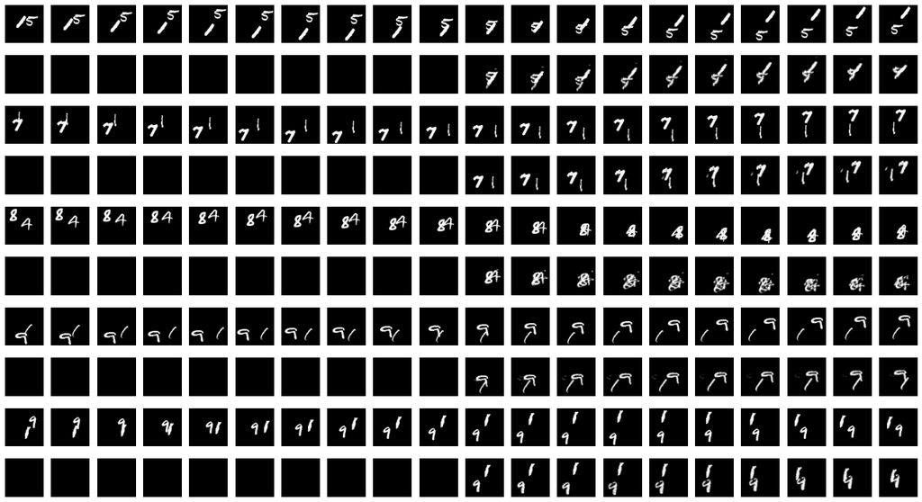

```python
random_batch = next(iter(evaluation.test_loader)).to(device)
gt_seq, pred_seq = evaluation.generate_future_sequences(random_batch)
save_grid_batch(random_batch, torch.cat((gt_seq,pred_seq),dim=0), batch_first=False, text="random_batch_mmnist",show=True)
```

```python
save_gif_batch(random_batch, torch.cat((gt_seq,pred_seq),dim=0), nsamples=10 ,batch_first=False, text="random_batch_mmnist",show=True)
```

```
------------Context Frames (First 10 frames of the sequence)----------------
```

[output not shown]

```
------------Future Ground Truth Frames (Next 10 frames of the sequence)----------------
```

[output not shown]

```
------------Predicted Frames----------------
```

[output not shown]

##### **5.1.3 Models Comparison**

[figure not shown]

#### **5.2 Results on KTH**

##### **5.2.1 Visualizae Best Metrices**

```python
SAVED_MODEL_PATH = "path/to/kth_pretrained.pth"
evaluation = eval(model_path = SAVED_MODEL_PATH)
evaluation.visualize_best_metrices()
```

[output not shown]

##### **5.2.2 Visualizae Output for Random Samples**

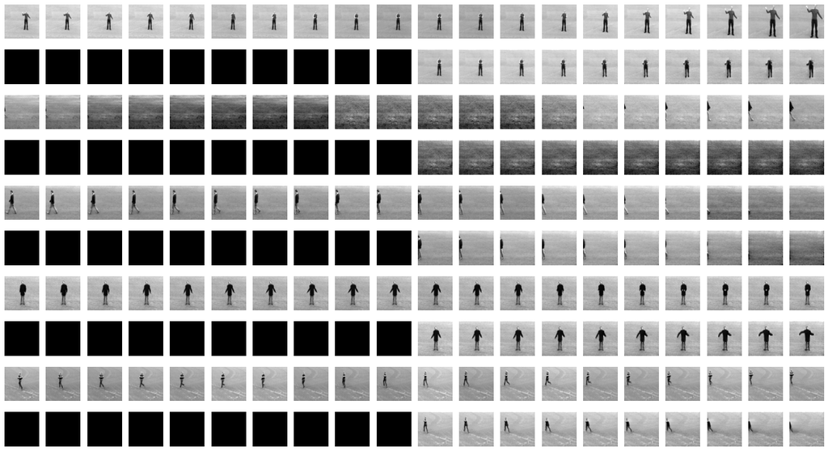

```python
random_batch = next(iter(evaluation.test_loader)).to(device)
gt_seq, pred_seq = evaluation.generate_future_sequences(random_batch)
save_grid_batch(random_batch, torch.cat((gt_seq,pred_seq),dim=0), batch_first=False, text="random_batch_kth",show=True)
```

```python
save_gif_batch(random_batch, torch.cat((gt_seq,pred_seq),dim=0), batch_first=False,nsamples=10 ,text="random_batch_kth",show=True)
```

```
------------Context Frames (First 10 frames of the sequence)----------------
```

[output not shown]

```
------------Future Ground Truth Frames (Next 10 frames of the sequence)----------------
```

[output not shown]

```
------------Predicted Frames----------------
```

[output not shown]

##### **5.2.3 Models Comparison**

[figure not shown]

### **6. References**

- https://github.com/edenton/svg
- [VLN](https://arxiv.org/abs/1612.01756)
- https://pytorch.org/
- https://www.tensorflow.org/tensorboard